# 🎋 L12: Hierarchical Forecasting

M-B5203E - Time Series, Analytics and Forecasting - 26-27

Anubhab Biswas

ISAAC, DACD, SUPSI

30th November, 2026

## Hierarchical Forecasting

In this lecture, we will cover the following topics:

- Introduction to hierarchical time series
- Coherence and forecast reconciliation
- Linear forecast reconciliation
- Nonlinear forecast reconciliation
- Practical session with Swiss population data

**📚 Resources**:

- [Forecast Reconciliation: A review](https://www.sciencedirect.com/science/article/pii/S0169207023001097)
- [fpppy chapter 11](https://otexts.com/fpppy/11-hierarchical-forecasting.html)

[figure not shown]

## Introduction

- Consider the population of Switzerland.

[figure not shown]

## Coherence

- At every past year $t=2025,2024,2023,...$ the population $P$ satisfies the following **aggregation constraints**:
  - $P^{CH}_t = P^{Aargau}_t+\dots + P^{Zürich}_t$
  - $P^{Zürich}_t = P^{Native, ZH}_t + P^{Foreigner, ZH}_t$ and so on…
- When the forecasts of these hierarchical time series follow the aggregation constraints, we call them *coherent*.
- **Examples**:
  - Sales of products from a retail company categorized by regions, stores, item-category.
  - Electric load at national, regional and household levels.
  - Number of a vaccinations in a city, region, and country against an epidemic.

## Coherence : do we really need it?

- Before we dive deep into the notations and the theory of hierarchical forecasting, let’s ask ourselves - do we really need coherence? Is it important?
- Let us talk see two incentives why it could be worth exploring.
- **Incentive 1**: *Coherence is natural*
  - Coherent forecasts represent the real behaviour of hierarchical time series.
  - In the sales example, incoherent forecasts can lead to the wrong modeling of demand and supply leading to wrong inventory policies. 😿
- **Incentive 2**: *Coherence can reduce error*
  - Sometimes, as we will see in today’s lesson coherent forecasts are guaranteed to be more accurate than incoherent forecasts. 😻

## Nodal representation

- A natural way to express hierarchical time series is through tree-like nodes.
- The figure below shows a simple hierarchical structure where the top node represents the “Total” which is the most aggregated level of the data.
- This is disaggregated into 2 series $P$ and $Q$ each of which is further subdivided into 2 nodes forming the 4 *bottom time series*.
- The time series at the all other levels are collectively known as *upper time series*, which in this case are **Total**, **P**, and **Q**.

[figure not shown]

## Nodal representation : Swiss population

[figure not shown]

## Notations

- We denote the $n_b$ bottom time series as $\textbf{B}_t$ and the $n_u$ upper time series as $\textbf{U}_t$.
- The total collection of all the $n=n_b+n_u$ time series $\textbf{Y}_t$ is written as;
  $$\mathbf{Y}_t =
  \begin{bmatrix}
  \mathbf{U}_t \\
  \mathbf{B}_t
  \end{bmatrix}$$
- The aggregation constraints ensure that each components of $\textbf{U}_t$ is a linear combination of the bottom time series.
- We know from matrix algebra, **linear combination = matrix pre-multiplication**, which implies,
  $$\textbf{U}_t = A \textbf{B}_t$$
- **Question**: how does the $A$ matrix look like?

## Notations

- In the previous example,
  - $\textbf{U}_t = \begin{bmatrix} Total_t & P_t & Q_t \end{bmatrix}^T$ and
  - $\textbf{B}_t=\begin{bmatrix} PA_t & PB_t & QA_t & QB_t \end{bmatrix}^T$.
- Thus, $n_u = 3$ and $n_b = 4$, and the aggregation constraint is
  $$\textbf{U}_t = \begin{bmatrix}
  Total_t \\
  P_t \\
  Q_t
  \end{bmatrix}
  = \begin{bmatrix}
  PA_t + PB_t + QA_t + QB_t \\
  PA_t + PB_t \\
  QA_t + QB_t
  \end{bmatrix}$$
- So, to write $\textbf{U}_t = A \textbf{B}_t$,
  $$\textbf{U}_t = \begin{bmatrix}
  1 & 1 & 1 & 1 \\
  1 & 1 & 0 & 0 \\
  0 & 0 & 1 & 1
  \end{bmatrix} \begin{bmatrix}
  PA_t \\ PB_t \\ QA_t \\ QB_t
  \end{bmatrix}$$

## Aggregation matrix A

- This matrix $A$ is known as the *aggregation matrix*.
- We can also write $\textbf{Y}_t = S\textbf{B}_t$.
- Can you guess how will $S$ look like?

## Classical methods

- The classical and simple methods for hierarchical forecasting included single-level approaches.
- This essentially means:
  - Forecast **one single level** of the hierarchy
  - **Aggregate / disaggregate** the forecasts to obtain the forecast for other levels
- Depending on the level we forecast first, these methods are known as
  - *bottom-up (BU)*,
  - *top-down (TD)*, or
  - *middle-out (MO)* approaches.

## Common issues

- The classical methods for hierarchical forecasting have some common issues.
  - *Information loss*: We use information from just one level of the hierarchy.
  - *Accuracy*: There is no guarantee that the forecasts will be more accurate if we prefer one approach over the other.
  - *BU*: Bottom level time series are often noisy hence difficult to forecast.
  - *TD*: Loss of information due to disaggregation.
- *Questions*:
  - $1$. Can we have a method that can use information coming from all the time series?
  - $2$. Can we have a method that guarantees improvement in accuracy against a baseline?
  - $3$. Can we have a method that does both?

## Geometry of coherence

- Consider a very simple example with two bottom time series $B_1$ and $B_2$ and one upper time series $U = B_1 + B_2$.
- Due to the aggregation constraint, $\mathbf{Y}_t$ has to lie on the plane

$$\mathcal{S}
=
\left\{
(B_1+B_2, B_1, B_2)^\top
:
B_1,B_2 \in \mathbb{R}
\right\}
\subset \mathbb{R}^3$$

in order to be coherent.

- $\mathcal{S}$ is known as the coherent plane, or more generally the **coherent subspace**.

[interactive chart not shown]

## Forecast Reconciliation

- In the previous example, what happens if we forecast $\mathbf{U}_t$ and $\mathbf{B}_t$ independently?
- Almost certainly, the aggregation constraints will no longer hold!
- The forecasts can lie anywhere in the ambient space $\mathbb{R}^3$.
- Can we force these forecasts to become coherent again?
- Yes, and the post-forecasting tool to make these independently generated forecasts coherent is known as *forecast reconciliation*.
- The independently generated incoherent forecasts are called *base forecasts*.
- It is *faster* and *easier* to reconcile than to train a model that produces coherent forecasts by design when the hierarchy has a large number of constraints.

## Forecast Reconciliation - geometric idea

[interactive chart not shown]

- We denote the base forecasts with *hat* $(\hat{.})$ and the coherent forecasts (reconciled) with *tilde* $(\tilde{.})$.

## Classical approaches using mapping matrices

All the classical methods for hierarchical forecasting can be written in terms of the mapping matrices.

### Bottom-up

$$\small
G_{\text{BU}} =
\begin{bmatrix}
0 & 0 & 0 & 1 & 0 & 0 & 0 \\
0 & 0 & 0 & 0 & 1 & 0 & 0 \\
0 & 0 & 0 & 0 & 0 & 1 & 0 \\
0 & 0 & 0 & 0 & 0 & 0 & 1
\end{bmatrix}$$

$$\tilde{\mathbf{y}}_h = S G \hat{\mathbf{y}}_h$$

- $G$ simply **keeps the bottom-level forecasts** and ignores the upper-level ones as the first three columns are “zero”-ed out.
- The summing matrix $S$ then aggregates the selected bottom forecasts to obtain $\tilde{\mathbf{y}}_h$.

## Classical approaches using mapping matrices

We can also describe the top-down approach in a similar way.

### Top-down

$$\small
G_{\text{TD}} =
\begin{bmatrix}
p_1 & 0 & 0 & 0 & 0 & 0 & 0 \\
p_2 & 0 & 0 & 0 & 0 & 0 & 0 \\
p_3 & 0 & 0 & 0 & 0 & 0 & 0 \\
p_4 & 0 & 0 & 0 & 0 & 0 & 0
\end{bmatrix}$$

$$\tilde{\mathbf{y}}_h = S G \hat{\mathbf{y}}_h$$

- The first column of $G$ includes the set of proportions that distribute the base forecasts of the top level to the bottom.
- The rest of the columns “zero” out the base forecasts below the top level of aggregation.
- A middle-out approach will be a combination of these two.

## Reconciliation via Projection

- The most common approach to modern forecast reconciliation is through projections.
- Recall that we can write linear forecast reconciliation as
  $$\tilde{\mathbf{y}}_h = S G \hat{\mathbf{y}}_h,$$
  where $G$ is a suitable mapping matrix.
- $SG$ is a **linear projection matrix** if and only if $SGS=S$.
- Let’s write the following regression model,
  $$\hat{\mathbf{y}}_h = S\beta + {\mathbf{\epsilon}}_h$$
  where $\beta$ is the unknown mean of the bottom time series, and ${\mathbf{\epsilon}}_h$ is the coherency error.

## Reconciliation via Projection

- If $\Sigma_h$ is the covariance matrix of the coherency error, then the regression estimate for $\beta$ is,
  $$\hat{\beta} = (S^T\Sigma_h^{-1}S)^{-1}S^T\Sigma_h^{-1}\hat{\textbf{y}}_h$$
- We can write the reconciled forecast as:
  $$\begin{aligned}
  \tilde{\textbf{y}}_h &= S\hat{\beta} \\
  &= S(S^T\Sigma_h^{-1}S)^{-1}S^T\Sigma_h^{-1}\hat{\textbf{y}}_h
  \end{aligned}$$
- If we write $G = (S^T\Sigma_h^{-1}S)^{-1}S^T\Sigma_h^{-1}$ , then the above equation follows the usual notion of $\tilde{\mathbf{y}}_h = S G \hat{\mathbf{y}}_h$.
- It can easily be shown that this choice of $G$ indeed satisfies $SGS=S$.

## Choices of $\Sigma_h$

- How to estimate $\Sigma_h$?
- There are the following choices:

| Method | $\hat\Sigma_h$ | $\tilde{\textbf{y}}_h$ | Note |
| --- | --- | --- | --- |
| **OLS** | $I_h$ | $S(S^TS)^{-1}S^T\hat{\textbf{y}}_h$ | Not scaled, no covariance |
| **WLS** | $V_h$ | $S(S^TV_h^{-1}S)^{-1}S^TV_h^{-1}\hat{\textbf{y}}_h$ | Scaled, no covariance |
| **FULL** | $W_h$ | $S(S^TW_h^{-1}S)^{-1}S^TW_h^{-1}\hat{\textbf{y}}_h$ | Scaled, Covariance |

- **Question**: How to obtain $W_h$?
- Impossible from the regression approach.

## min-Trace

- So, researchers formulated the projection problem from an optimization point of view.
- The geometric idea is to have the minimum displacement linear projection from $\hat{\textbf{y}}_h$ to $\tilde{\textbf{y}}_h$ such that the TSS is reduced.

$$\tilde{\textbf{y}}_h = \arg\min_{{\textbf{x}}}||\hat{\textbf{y}}_h-{\textbf{x}}||^2_W = (\hat{\textbf{y}}_h-{\textbf{x}})^TW_h^{-1}(\hat{\textbf{y}}_h-{\textbf{x}})$$

- Same solutions as the regression approach, but we can estimate $W_h = E[\hat{\textbf{e}}_h\hat{\textbf{e}}_h^T]$ where,
  $$\hat{\textbf{e}}_h = \textbf{y} - \hat{\textbf{y}}_h$$
  are the in-sample residuals of the fitted base forecast.
- Further, with the assumption $W_h = k_h W_1$ ($k_h=1$), the estimate of the covariance matrix become more stable for bigger horizons.

## Geometric interpretation<sup>1</sup>

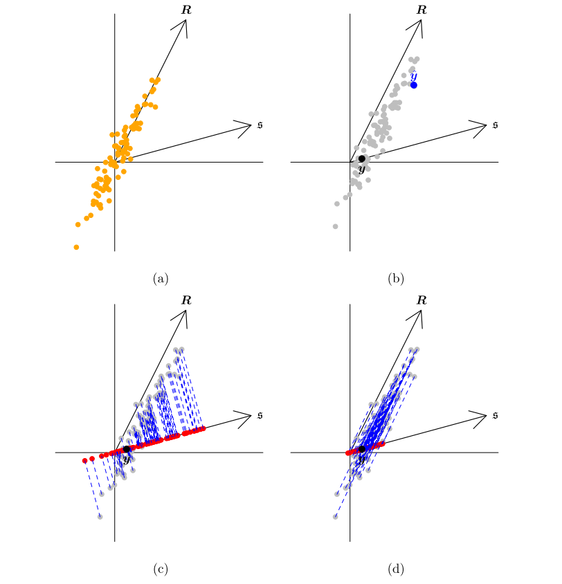

$R$: most likely direction of deviations from the coherent subspace $\mathcal{S}$

- (a): in-sample residuals
- (b): base forecasts
- (c): orthogonal projection
  - OLS
  - no preferred direction$
- (d): oblique projection
  - WLS, MinT
  - preferred direction according to $R$
[^1]: Panagiotelis et al. (2021), *Forecast reconciliation: A geometric view with new insights on bias correction*.

## Error reduction theorem

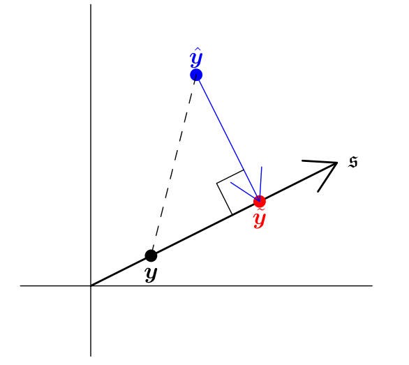

- Reconciled forecast are guaranteed to have a *higher accuracy* than that of the base forecast.
- For both oblique and orthogonal projection this is valid when the scores are **distance-based under it’s respective norm**.
- It can be easily visualized for the OLS with Pythagorous theorem<sup>1</sup>.
[^2]: Panagiotelis et al. (2021), *Forecast reconciliation: A geometric view with new insights on bias correction*.

## Forecast Reconciliation workflow

- To summarize forecast reconciliation, a flowchart is provided below.

[figure not shown]

## Probabilistic Reconciliation

Can be done in two ways:

- Apply projection to each sample point

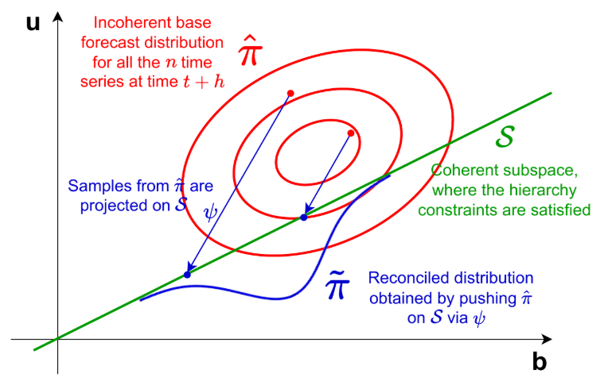

- Reconcile the base forecast distribution to obtain a coherent density/mass using Bayesian methods (*reconciliation via conditioning*).

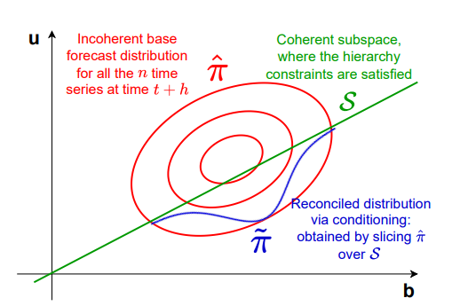

## Nonlinear Reconciliation

- What if we want to forecast the demographic or economic ratios related to populations?
- For example, consider the following constrained structure:

[figure not shown]

$I:\text{no. of immigrants}$, $P:\text{population}$, and $R:\text{immigration ratio}$ with the particular **Canton** / **country** as superscript.

- A linear reconciliation method is not sufficient anymore.

## Nonlinear Reconciliation

- Recently methods have been proposed to perform forecast reconciliation for time series with nonlinear constraints.
- A *nonlinear coherent manifold* such as $\mathcal{M}=\{(f_u(\textbf{B}_1,\textbf{B}_2),\textbf{B}_1,\textbf{B}_2)^T:\textbf{B}_1,\textbf{B}_2\in\mathbb{R}\}$ substitutes the linear coherent subspace in this case.

[interactive chart not shown]

## Error Reduction theorem

- A common approach is to project the incoherent base forecasts onto this nonlinear manifold $\mathcal{M}$.
- Can we have an error reduction theorem for the nonlinear case?
- The short answer is *NO*, because the Pythagorean theorem cannot be applied here.
- Although there are some special cases for which an improvement in terms of accuracy is guaranteed over the base forecast.
- Exploring those cases are currently out of scope of this lecture.

## Exercise

- In the practical session we will try to do the following tasks:
  - Structure the Swiss population data into nodal representation.
  - Obtain base forecasts using the models from the previous lecture.
  - Compute the reconciled forecast from scratch.
  - Compare the result with the one obtained from a standard reconciliation package.
  - Check the error reduction theorem.